# IST687 Section M002

```r
print(' just curious, if we are asking hist of number of bikes available, why are we counting instances where there were 0 bikes, seems like unnecessary.
      what are your opinions? I wrote this because thats how everyone did !' )
```

```
## [1] " just curious, if we are asking hist of number of bikes available, why are we counting instances where there were 0 bikes, seems like unnecessary. \n      what are your opinions? I wrote this because thats how everyone did !"
```

8. How many stations have at least one ebike?

```r
sum(stationStatus$num_ebikes_available>= 1)
```

```
## [1] 309
```

9. Explore stations with at least one ebike by create a new dataframe, that only has stations with at least one eBike.

```r
eBikesDF<- stationStatus[stationStatus$num_ebikes_available>=1, ]
min(eBikesDF$num_ebikes_available)
```

```
## [1] 1
```

10. Calculate the mean of ‘num_docks_available’ for this new dataframe.

```r
mean(eBikesDF$num_docks_available)
```

```
## [1] 16.55016
```

11. Calculate the mean of ‘num_docks_available’ for for the full ‘stationStatus’ dataframe. In a comment, explain how different are the two means?

```r
mean(stationStatus$num_docks_available)
```

```
## [1] 15.73764
```

```r
stationStatus$stationSize <- stationStatus$num_bikes_available +stationStatus$num_bikes_disabled + stationStatus$num_ebikes_available + stationStatus$num_docks_available + stationStatus$num_docks_disabled
```

13. Use the plot( ) command to produce an X-Y scatter plot with the number of  
    occupied docks on the X-axis and the number of available bikes on the Y-axis. Explain the results plot

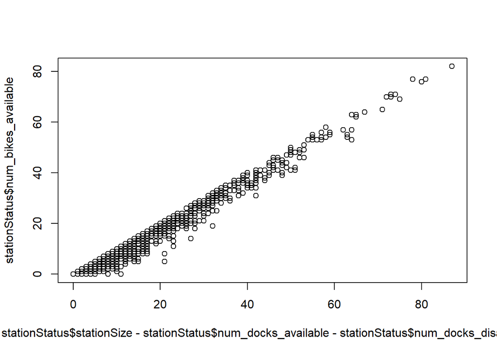

```r
# plot(X axis, Y axis )
# X axis --> Occupied slots=  stationStatus$stationSize- stationStatus$num_docks_available - stationStatus$num_docks_disabled
#Y axis --> stationStatus$num_bikes_available
plot(stationStatus$stationSize- stationStatus$num_docks_available - stationStatus$num_docks_disabled,stationStatus$num_bikes_available)
```